# Homework2 Logistic Regresion

### DF Betas

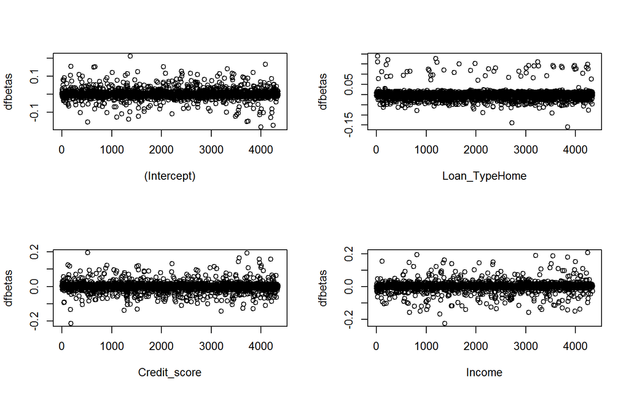

```r
#DF Betas
par(mfrow=c(2,2))
plot(df.beta[,1], xlab = colnames(df.beta)[1], ylab = "dfbetas")
plot(df.beta[,2], xlab = colnames(df.beta)[2], ylab = "dfbetas")
plot(df.beta[,3], xlab = colnames(df.beta)[3], ylab = "dfbetas")
plot(df.beta[,4], xlab = colnames(df.beta)[4], ylab = "dfbetas")
```

```r
par(mfrow=c(1,1))
```

These DF betas indicate whether any cases are causing instability in the parameter estimates. Based on these results, no single case is causing significant concern.

### Correlation

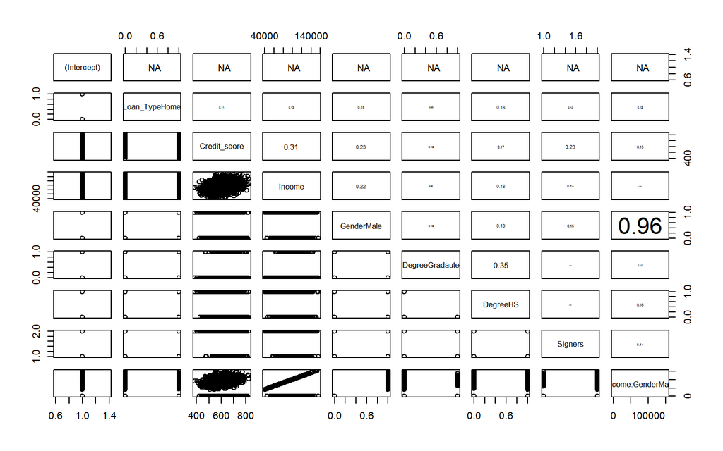

```r
panel.cor <- function(x, y, digits = 2, prefix = "", cex.cor, ...)
{
    usr <- par("usr"); on.exit(par(usr))
    par(usr = c(0, 1, 0, 1))
    r <- abs(cor(x, y))
    txt <- format(c(r, 0.123456789), digits = digits)[1]
    txt <- paste0(prefix, txt)
    if(missing(cex.cor)) cex.cor <- 0.8/strwidth(txt)
    text(0.5, 0.5, txt, cex = cex.cor * r)
}
pairs(model.matrix(final.model),upper.panel=panel.cor)
```

```r
#VIF
vif(final.model)
```

```
                   GVIF Df GVIF^(1/(2*Df))
Loan_Type      1.043619  1        1.021577
Credit_score   1.107157  1        1.052215
Income         1.756170  1        1.325206
Gender        46.593680  1        6.825956
Degree         1.093925  2        1.022697
Signers        1.081543  1        1.039972
Income:Gender 46.740293  1        6.836687
```

We select the critical variables of stage 1 (automatic method). The information has been segmented by loan type. A logistic regression model is proposed to predict the default of home loans. The model includes the following variables: Credit_score + Income + Gender + Degree.

```r
load("Logistic_Home.RData")
str(Logistic)
```

```
Classes 'tbl_df', 'tbl' and 'data.frame':   1390 obs. of  11 variables:
 $ ID          : num  2 3 4 16 23 24 25 33 35 39 ...
  ..- attr(*, "format.spss")= chr "F5.0"
  ..- attr(*, "display_width")= int 12
 $ Default     : num  0 0 0 0 0 1 1 0 0 1 ...
  ..- attr(*, "format.spss")= chr "F2.0"
  ..- attr(*, "display_width")= int 12
 $ Loan_Type   : chr  "Home" "Home" "Home" "Home" ...
  ..- attr(*, "format.spss")= chr "A4"
  ..- attr(*, "display_width")= int 10
 $ Gender      : chr  "Female" "Male" "Male" "Female" ...
  ..- attr(*, "format.spss")= chr "A6"
 $ Age         : num  43 39 39 45 46 53 36 41 56 36 ...
  ..- attr(*, "format.spss")= chr "F3.0"
  ..- attr(*, "display_width")= int 12
 $ Degree      : chr  "HS" "HS" "College" "College" ...
  ..- attr(*, "format.spss")= chr "A8"
 $ Income      : num  95770 94220 58946 93253 99880 ...
  ..- attr(*, "format.spss")= chr "F7.0"
  ..- attr(*, "display_width")= int 12
 $ Credit_score: num  534 558 622 580 551 701 682 586 586 667 ...
  ..- attr(*, "format.spss")= chr "F4.0"
  ..- attr(*, "display_width")= int 12
 $ Loan_lenght : num  7 5 7 10 8 8 8 7 11 5 ...
  ..- attr(*, "format.spss")= chr "F3.0"
  ..- attr(*, "display_width")= int 12
 $ Signers     : num  2 2 2 1 2 1 1 2 2 2 ...
  ..- attr(*, "format.spss")= chr "F2.0"
  ..- attr(*, "display_width")= int 12
 $ Citizenship : chr  "Citizen" "Citizen" "Citizen" "Citizen" ...
  ..- attr(*, "format.spss")= chr "A11"
  ..- attr(*, "display_width")= int 11
```

```r
summary(Logistic)
```

```
       ID          Default         Loan_Type            Gender
 Min.   :   2   Min.   :0.00000   Length:1390        Length:1390
 1st Qu.:1091   1st Qu.:0.00000   Class :character   Class :character
 Median :2204   Median :0.00000   Mode  :character   Mode  :character
 Mean   :2209   Mean   :0.03741
 3rd Qu.:3329   3rd Qu.:0.00000
 Max.   :4362   Max.   :1.00000
      Age           Degree              Income        Credit_score
 Min.   :23.00   Length:1390        Min.   : 43635   Min.   :389.0
 1st Qu.:36.00   Class :character   1st Qu.: 81613   1st Qu.:559.0
 Median :41.00   Mode  :character   Median : 93447   Median :599.0
 Mean   :40.47                      Mean   : 93028   Mean   :600.8
 3rd Qu.:44.00                      3rd Qu.:104905   3rd Qu.:641.0
 Max.   :60.00                      Max.   :153485   Max.   :814.0
  Loan_lenght        Signers      Citizenship
 Min.   : 0.000   Min.   :1.000   Length:1390
 1st Qu.: 4.000   1st Qu.:2.000   Class :character
 Median : 6.000   Median :2.000   Mode  :character
 Mean   : 5.835   Mean   :1.947
 3rd Qu.: 8.000   3rd Qu.:2.000
 Max.   :14.000   Max.   :2.000
```

```r
View(Logistic)
```